# Typing_speed

Sara, Su

2026-10-08

## 1. Main Question

Do keyboard type (Internal vs. External) and environment (Quiet vs. Noisy) affect mean Net WPM? Does the effect of keyboard type depend on the environment?

## 2. Response Variable

The response variable is Net Words Per Minute (Net WPM), an error-adjusted measure of typing speed. The recorded values are already Net WPM, so no additional error deduction is applied in the analysis.

## 3. Experimental Design

This experiment used a 2 × 2 factorial design with two factors:

- Keyboard type: External and Internal.
- Environment: Quiet and Noisy.

Six participants took part: Adnan, Abey, Jason, Sara, Steven, and Prince. Each participant completed all four conditions once, producing 24 observations in total.

Each condition was tested by six participants. There were no repeated trials within the same participant and condition.

Participant was included as a blocking factor in the ANOVA to account for differences in baseline typing speed.

## 4. Randomization and Procedure

The order of the four conditions was randomized for each participant to reduce systematic order effects, such as practice and fatigue.

Each participant completed one 3-minute typing test under each keyboard and environment combination. Net WPM was recorded after each test.

All six participants completed all four conditions. The dataset contains 24 observations, with no missing Net WPM values.

## 5. Hypotheses

All tests use a significance level of alpha = 0.05.

### Keyboard Type

H0: Mean Net WPM is equal for Internal and External keyboards, averaged across environments.

Ha: Mean Net WPM differs between Internal and External keyboards, averaged across environments.

### Environment

H0: Mean Net WPM is equal for Quiet and Noisy environments, averaged across keyboard types.

Ha: Mean Net WPM differs between Quiet and Noisy environments, averaged across keyboard types.

### Interaction

H0: The difference in mean Net WPM between Internal and External keyboards is the same in both environments.

Ha: The difference in mean Net WPM between Internal and External keyboards depends on the environment.

## 6. Analysis Method

We calculated mean Net WPM for each keyboard and environment combination.

We used ANOVA with keyboard type, environment, and their interaction. Participant was included as a blocking factor to account for baseline differences in typing speed.

The fitted model was:

Net WPM ~ Participant + Keyboard + Environment + Keyboard:Environment

F-tests were used to test the three hypotheses at alpha = 0.05. An interaction plot was used to compare the keyboard differences across environments.

Residual plots and a Shapiro-Wilk test were used to assess model assumptions. The model assumes additive participant effects and independent errors with constant variance and an approximately normal distribution.

```r
typing <- read.csv(
  "Typing_speed.csv",
  check.names = FALSE
)

names(typing)[5] <- "Net_WPM"

typing$Participant <- factor(trimws(typing$Participant))
typing$Keyboard <- factor(
  trimws(typing$Keyboard),
  levels = c("External", "Internal")
)
typing$Environment <- factor(
  trimws(typing$Environment),
  levels = c("Quiet", "Noisy")
)

typing <- typing[
  c("Participant", "Trial", "Keyboard", "Environment", "Net_WPM")
]

typing
```

```
##    Participant Trial Keyboard Environment Net_WPM
## 1        Adnan     1 External       Quiet      29
## 2         Abey     1 External       Quiet      54
## 3        Jason     1 External       Quiet      57
## 4         Sara     1 External       Quiet      23
## 5       Steven     1 External       Quiet      29
## 6       Prince     1 External       Quiet      36
## 7        Adnan     2 Internal       Quiet      38
## 8         Abey     2 Internal       Quiet      49
## 9        Jason     2 Internal       Quiet      60
## 10        Sara     2 Internal       Quiet      29
## 11      Prince     2 Internal       Quiet      42
## 12      Steven     2 Internal       Quiet      38
## 13       Adnan     3 External       Noisy      31
## 14        Abey     3 External       Noisy      51
## 15       Jason     3 External       Noisy      52
## 16        Sara     3 External       Noisy      24
## 17      Steven     3 External       Noisy      31
## 18      Prince     3 External       Noisy      37
## 19      Steven     4 Internal       Noisy      43
## 20       Adnan     4 Internal       Noisy      35
## 21        Abey     4 Internal       Noisy      51
## 22       Jason     4 Internal       Noisy      60
## 23        Sara     4 Internal       Noisy      31
## 24      Prince     4 Internal       Noisy      36
```

```r
nrow(typing)
```

```
## [1] 24
```

```r
nlevels(typing$Participant)
```

```
## [1] 6
```

```r
colSums(is.na(typing))
```

```
## Participant       Trial    Keyboard Environment     Net_WPM
##           0           0           0           0           0
```

```r
with(typing, table(Participant, Keyboard, Environment))
```

```
## , , Environment = Quiet
##
##            Keyboard
## Participant External Internal
##      Abey          1        1
##      Adnan         1        1
##      Jason         1        1
##      Prince        1        1
##      Sara          1        1
##      Steven        1        1
##
## , , Environment = Noisy
##
##            Keyboard
## Participant External Internal
##      Abey          1        1
##      Adnan         1        1
##      Jason         1        1
##      Prince        1        1
##      Sara          1        1
##      Steven        1        1
```

```r
aggregate(
  Net_WPM ~ Keyboard + Environment,
  data = typing,
  FUN = mean
)
```

```
##   Keyboard Environment  Net_WPM
## 1 External       Quiet 38.00000
## 2 Internal       Quiet 42.66667
## 3 External       Noisy 37.66667
## 4 Internal       Noisy 42.66667
```

```r
aggregate(
  Net_WPM ~ Keyboard,
  data = typing,
  FUN = mean
)
```

```
##   Keyboard  Net_WPM
## 1 External 37.83333
## 2 Internal 42.66667
```

```r
aggregate(
  Net_WPM ~ Environment,
  data = typing,
  FUN = mean
)
```

```
##   Environment  Net_WPM
## 1       Quiet 40.33333
## 2       Noisy 40.16667
```

```r
model <- aov(
  Net_WPM ~ Participant + Keyboard * Environment,
  data = typing
)

summary(model)
```

```
##                      Df Sum Sq Mean Sq F value   Pr(>F)
## Participant           5 2690.0   538.0  51.076 6.87e-09 ***
## Keyboard              1  140.2   140.2  13.307  0.00238 **
## Environment           1    0.2     0.2   0.016  0.90157
## Keyboard:Environment  1    0.2     0.2   0.016  0.90157
## Residuals            15  158.0    10.5
## ---
## Signif. codes:  0 '***' 0.001 '**' 0.01 '*' 0.05 '.' 0.1 ' ' 1
```

## 7. ANOVA Results

After accounting for participant differences, keyboard type was significant, F(1, 15) = 13.307, p = 0.00238. We reject the null hypothesis for keyboard type.

Mean Net WPM was 42.67 for Internal keyboards and 37.83 for External keyboards, a difference of approximately 4.83 Net WPM.

Environment was not significant, F(1, 15) = 0.016, p = 0.90157. We fail to reject the null hypothesis for environment.

The keyboard-by-environment interaction was not significant, F(1, 15) = 0.016, p = 0.90157. We fail to reject the null hypothesis for interaction.

These results provide evidence of a keyboard difference under the fitted model, but insufficient evidence of an environment effect or an interaction.

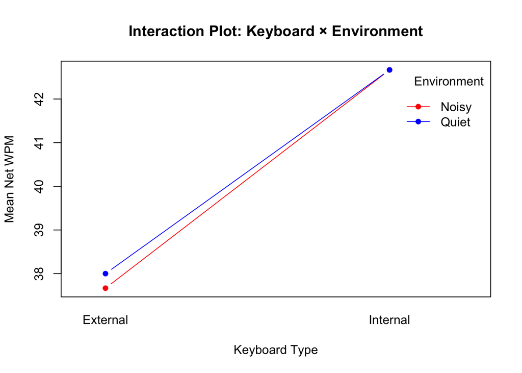

```r
with(typing, interaction.plot(
  x.factor = Keyboard,
  trace.factor = factor(
    Environment,
    levels = c("Noisy", "Quiet")
  ),
  response = Net_WPM,
  fun = mean,
  type = "b",
  pch = c(16, 16),
  col = c("red", "blue"),
  lty = c(1, 1),
  xlab = "Keyboard Type",
  ylab = "Mean Net WPM",
  trace.label = "Environment",
  main = "Interaction Plot: Keyboard × Environment"
))
```

## 8. Interaction Plot Interpretation

Mean Net WPM increased from External to Internal keyboards in both environments.

In the Quiet environment, the mean increased from 38.00 to 42.67 Net WPM. In the Noisy environment, it increased from 37.67 to 42.67 Net WPM.

The two lines are nearly parallel, suggesting similar keyboard differences across environments. This agrees with the nonsignificant interaction test (p = 0.90157).

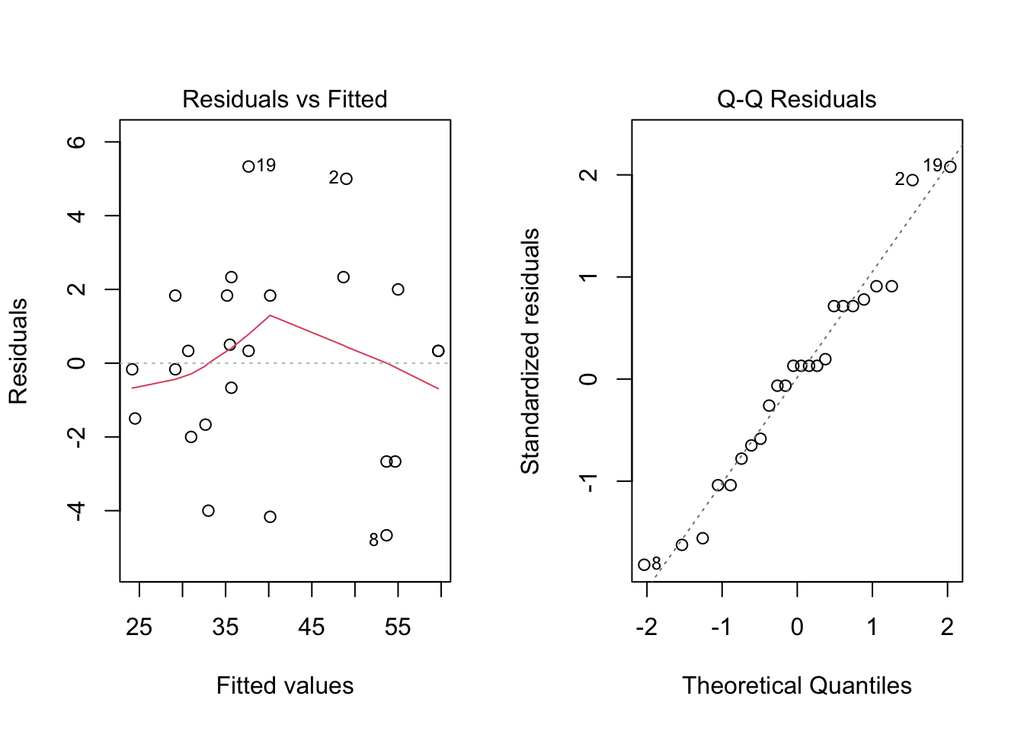

```r
par(mfrow = c(1, 2))

plot(model, which = 1)
plot(model, which = 2)
```

```r
par(mfrow = c(1, 1))

shapiro.test(residuals(model))
```

```
##
##  Shapiro-Wilk normality test
##
## data:  residuals(model)
## W = 0.96589, p-value = 0.5674
```

## 9. Model Diagnostics

The residuals-versus-fitted plot showed a slight curve but no clear funnel pattern. The Q-Q plot showed points approximately following the reference line, with some deviations in the tails.

The Shapiro-Wilk test gave W = 0.96589 and p = 0.5674. At alpha = 0.05, we found insufficient evidence that the residuals depart from a normal distribution.

These checks did not reveal strong evidence of severe non-normality or unequal variance. However, the small sample limits the ability to detect assumption violations. These plots do not establish independence of errors.

## 10. Limitations and Future Improvements

The experiment included only six participants, with one trial per participant in each condition. This limits generalization and our ability to detect small environment or interaction effects.

The 24 observations came from repeated measurements of six people, rather than 24 independent participants. Our model accounts for baseline participant differences but assumes that participant effects are additive.

Keyboard familiarity may have influenced performance, but it was not measured in this dataset.

If we repeated the experiment, we would recruit more participants, repeat each condition within participants, and record keyboard familiarity and actual test order. We would also standardize passage difficulty, noise level, and rest periods.

## 11. Conclusion

Under the fitted participant-blocked ANOVA model, keyboard type was associated with a significant difference in mean Net WPM.

Internal keyboards averaged 42.67 Net WPM, compared with 37.83 for External keyboards, a difference of approximately 4.83 Net WPM.

We found insufficient evidence of an environment effect or a keyboard-by-environment interaction. The conclusions are limited to the participants and conditions studied.